# Analysis of New York Shooting Data

9/26/2021

## Summary

In this document I test 2 seperate datasets to see if any statistically significant results can be found. I first focused on features within the datasets to try and predict shootings. I focused on 3 variables that I felt would be predictive of a shooting: Location, Hour of the day, and BORO. Next, I joined covid data from another project to see if covid and the underlying policy changes had an impact on shootings.

## Biases

I noticed that my choice of variables were due to my own biases. We hear that certain parts of New York are more dangerous then others. We hear not to go into central park at night and that shootings can be gang related, concentrated in public housing.

Covid has changed the world and I have always wondered what the societal impact has been. The data that I included in my analysis is people transportation data, vaccination data, as well as case and death rates.

## Method

The first step I took was getting data from reproducible sources. I was able to get good data from both government agencies and news sources.

The second step was to clean the data, pivot, and group it by the same grain.

I then manufactured features for the model.I normalized the covid data against the total population where it made sense like vaccinations and population mobility.

I created new features to use in the prediction like percent change and number change in both cases and deaths.

## Conclusion

I came to 2 conclusions with this analysis:

This finding most likely is due to the time series associated with covid. As this pandemic has continued people have continued to suffer hardship and by coincidence more people have gotten vaccinated.

## Next Action

There are a lot of things to analyze with this data specifically within the Covid lens. The Covid data comes by county and it would be interesting to see if the relationship between covid and shootings is stronger in certain Boroughs. Further I would like to see if the relationship is stronger in different types of shooting situations like in public housing vs bars.

```r
url_in <- "https://data.cityofnewyork.us/api/views/833y-fsy8/rows.csv?accessType=DOWNLOAD"

baseData <- read_csv(url_in)
baseData <- select(baseData, 1:15)
url_in <- "https://data.cityofnewyork.us/api/views/5ucz-vwe8/rows.csv?accessType=DOWNLOAD"

currentData <-read_csv(url_in)
currentData <- select(currentData, 1:15)
baseData <- rbind(currentData, baseData)
```

```r
url_in <- "https://raw.githubusercontent.com/preuscht/covid-19-analysis/main/covid_data.csv"

baseCovidData <- read_csv(url_in)
```

```
## * `` -> ...1
```

In order to get the Hour of each shooting I had to separate the OCCUR_TIME field.

```r
cleanDate <- baseData %>% mutate(date = mdy(OCCUR_DATE))

cleanDate <- cleanDate %>% separate(OCCUR_TIME, c("Hour", "Minute", "Second"), ":")

summary(cleanDate)
```

```
##   INCIDENT_KEY        OCCUR_DATE            Hour              Minute
##  Min.   :  9953245   Length:24470       Length:24470       Length:24470
##  1st Qu.: 59218195   Class :character   Class :character   Class :character
##  Median : 85083100   Mode  :character   Mode  :character   Mode  :character
##  Mean   :106822418
##  3rd Qu.:156333072
##  Max.   :230278934
##
##     Second              BORO              PRECINCT      JURISDICTION_CODE
##  Length:24470       Length:24470       Min.   :  1.00   Min.   :0.0000
##  Class :character   Class :character   1st Qu.: 44.00   1st Qu.:0.0000
##  Mode  :character   Mode  :character   Median : 69.00   Median :0.0000
##                                        Mean   : 66.03   Mean   :0.3321
##                                        3rd Qu.: 81.00   3rd Qu.:0.0000
##                                        Max.   :123.00   Max.   :2.0000
##                                                         NA's   :2
##  LOCATION_DESC      STATISTICAL_MURDER_FLAG PERP_AGE_GROUP
##  Length:24470       Mode :logical           Length:24470
##  Class :character   FALSE:19800             Class :character
##  Mode  :character   TRUE :4670              Mode  :character
##
##
##
##
##    PERP_SEX          PERP_RACE         VIC_AGE_GROUP        VIC_SEX
##  Length:24470       Length:24470       Length:24470       Length:24470
##  Class :character   Class :character   Class :character   Class :character
##  Mode  :character   Mode  :character   Mode  :character   Mode  :character
##
##
##
##
##    VIC_RACE           X_COORD_CD           date
##  Length:24470       Min.   : 914928   Min.   :2006-01-01
##  Class :character   1st Qu.: 999925   1st Qu.:2009-02-28
##  Mode  :character   Median :1007674   Median :2012-06-03
##                     Mean   :1009377   Mean   :2013-01-26
##                     3rd Qu.:1016782   3rd Qu.:2016-08-30
##                     Max.   :1066815   Max.   :2021-06-30
##
```

Many locations were None or NA. I chose to drop them from my data set while graphing. There were upwards of 30 different locations which were too many for the graphs which I choose. I decided to limit to the top 10 for graphing purposes.

In this section I also group by hour as well created my multivariate data set for the model.

```r
shootingByLocation <- cleanDate %>% drop_na() %>% filter(LOCATION_DESC != "NONE") %>% group_by(LOCATION_DESC) %>% summarize(shootings = n())

top10Locations <- shootingByLocation %>% slice_max(shootings, n=10)

shootingByDate <- cleanDate %>% group_by(date) %>% summarize(shootings = n())

shootingByTime <- cleanDate %>% group_by(Hour) %>% summarize(shootings = n())

shootingByBORO <- cleanDate %>% group_by(BORO) %>% summarize(shootings = n())

multiVariateData <- cleanDate %>% drop_na() %>% group_by(LOCATION_DESC, BORO, Hour) %>% summarize(shootings = n())
ny_regression_data <-  filter(baseCovidData, stateAbbrev == "NY")

covid_shooting_regression_data <- ny_regression_data %>% inner_join(shootingByDate,by="date")
```

## Training Data Creation

```r
set.seed(222)

sample_size = round(nrow(multiVariateData)*.95)
index <- sample(seq_len(nrow(multiVariateData)), size = sample_size)

train <- multiVariateData[index, ]
test <- multiVariateData[-index, ]
```

```r
set.seed(222)

sample_size = round(nrow(covid_shooting_regression_data)*.90)
index <- sample(seq_len(nrow(covid_shooting_regression_data)), size = sample_size)

train_covid <- covid_shooting_regression_data[index, ]
test_covid <- covid_shooting_regression_data[-index, ]
```

## Including Plots

Below are my plots of each datapoint versus the count of shootings.

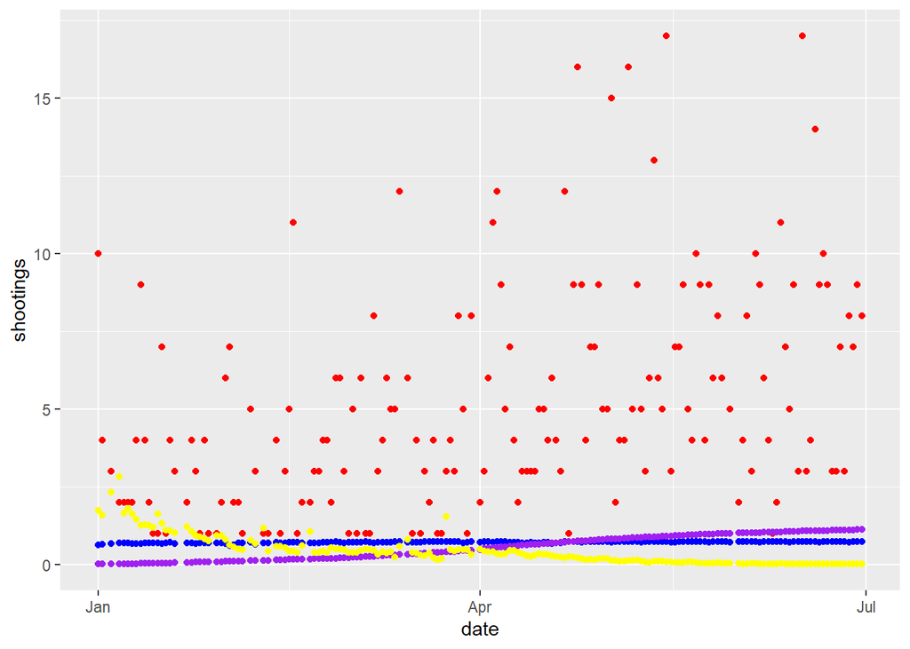

```r
covid_shooting_regression_data %>% ggplot() + geom_point(aes(x = date, y = shootings), color = "red")+
  geom_point(aes(x = date, y = not_home_rate), color = "blue")+geom_point(aes(x = date, y = vaccine_rate), color = "purple")+geom_point(aes(x = date, y = pct_change_cases), color = "yellow")
```

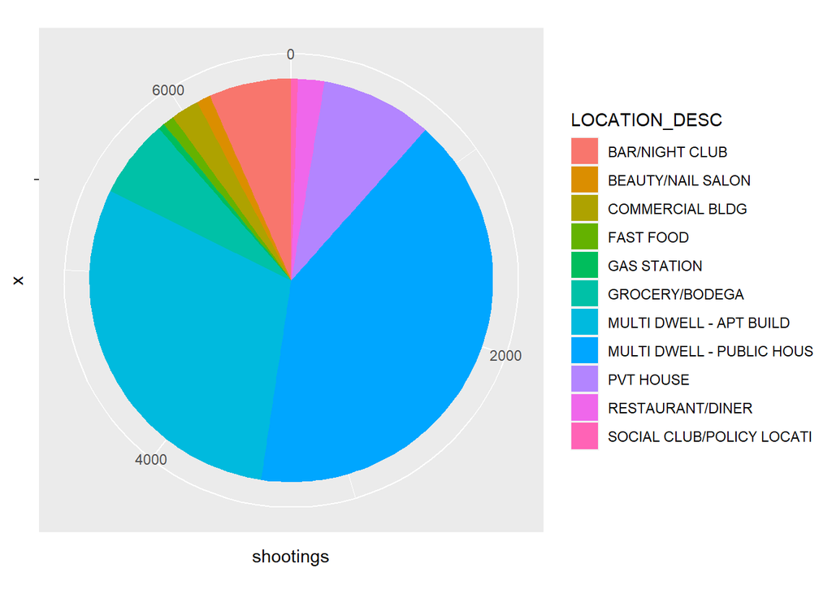

```r
ggplot(top10Locations, aes(x="", y=shootings, fill=LOCATION_DESC)) +
  geom_bar(stat="identity", width=1) +
  coord_polar("y", start=0)
```

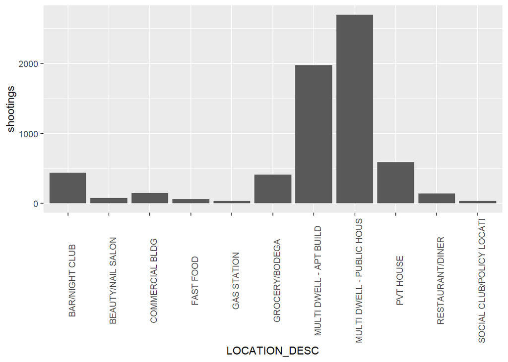

```r
ggplot(top10Locations, aes(x=LOCATION_DESC, y=shootings)) +
  geom_bar(stat = "identity") +
  theme(axis.text.x = element_text(angle = 90))
```

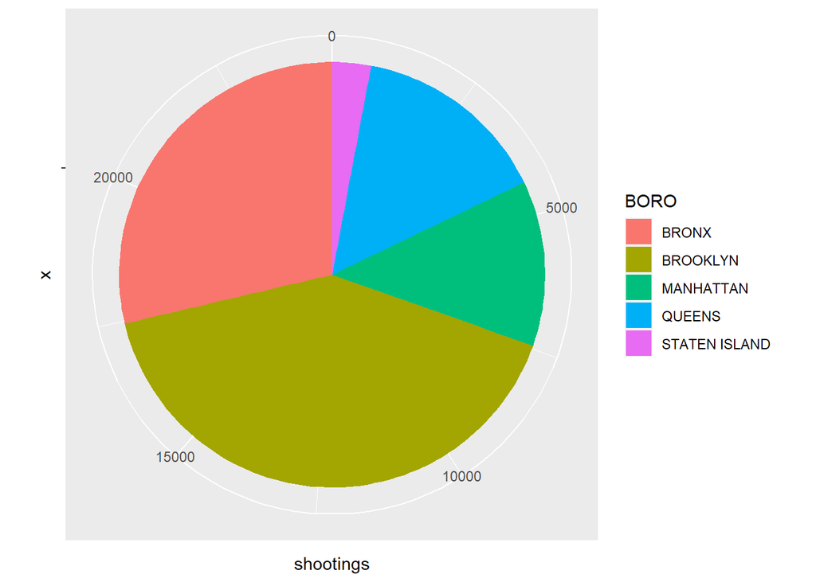

```r
ggplot(shootingByBORO, aes(x="", y=shootings, fill=BORO)) +
  geom_bar(stat="identity", width=1) +
  coord_polar("y", start=0)
```

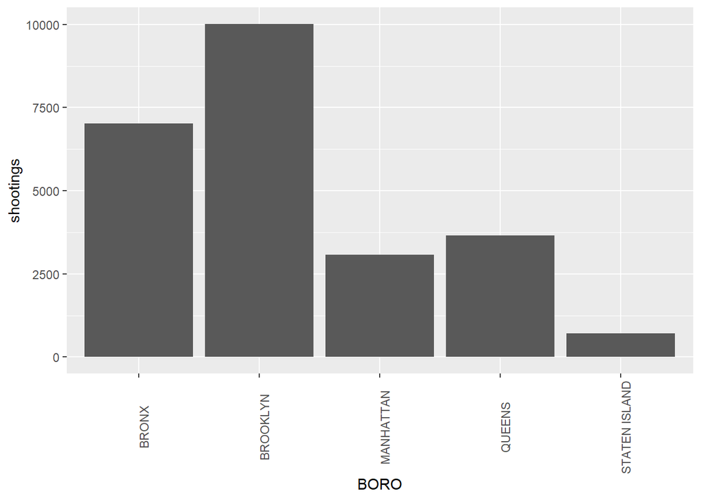

```r
ggplot(shootingByBORO, aes(x=BORO, y=shootings)) +
  geom_bar(stat = "identity") +
  theme(axis.text.x = element_text(angle = 90))
```

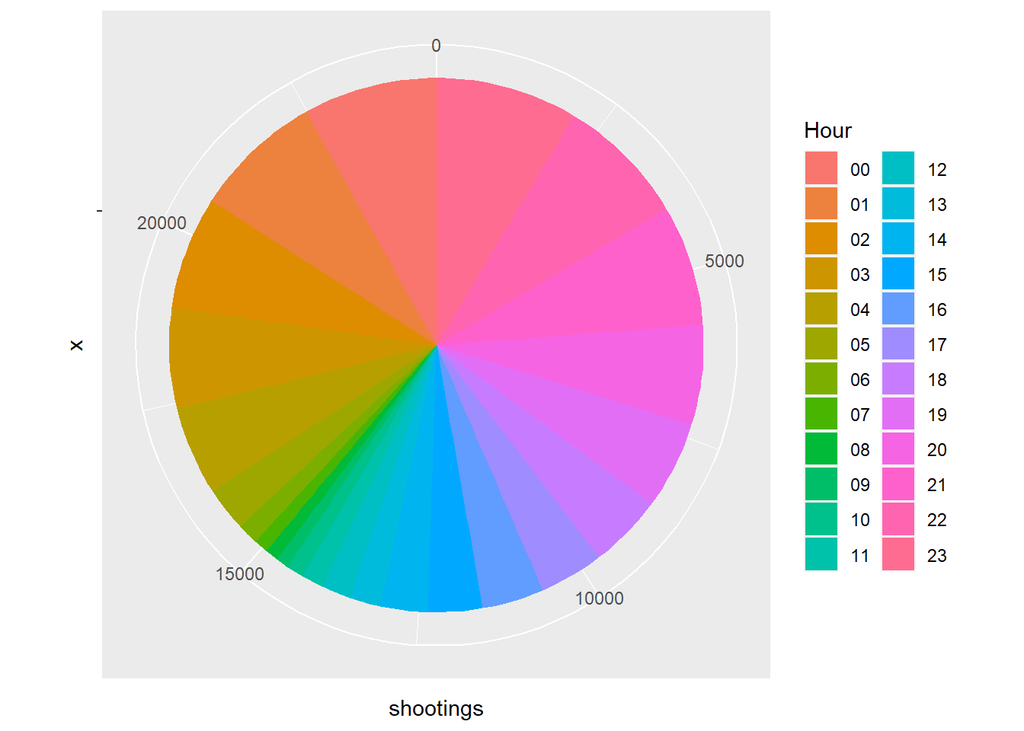

```r
ggplot(shootingByTime, aes(x="", y=shootings, fill=Hour)) +
  geom_bar(stat="identity", width=1) +
  coord_polar("y", start=0)
```

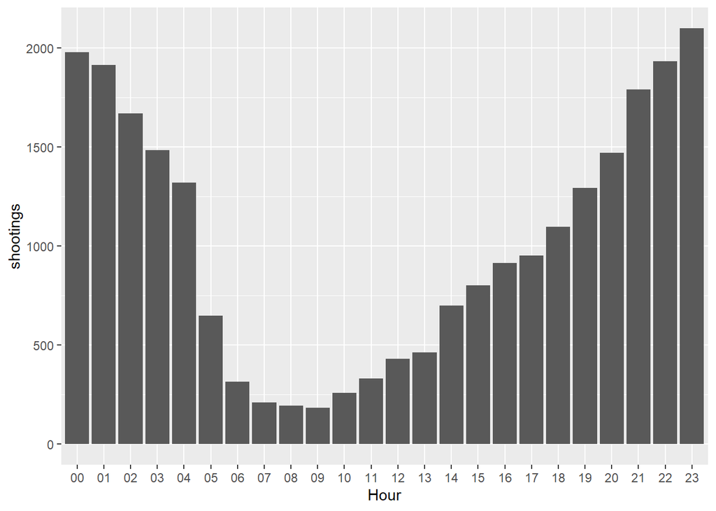

```r
ggplot(shootingByTime, aes(x=Hour, y=shootings)) +
  geom_bar(stat = "identity")
```

Below I run my multivariate linear model with three variables versus shootings. Time of day, Location, and BORO have statistically significant results.

```r
mod <- lm(shootings ~ Hour+BORO+LOCATION_DESC, data = train)

summary(mod)
```

```
##
## Call:
## lm(formula = shootings ~ Hour + BORO + LOCATION_DESC, data = train)
##
## Residuals:
##     Min      1Q  Median      3Q     Max
## -20.213  -5.090  -0.927   3.147  63.755
##
## Coefficients:
##                                         Estimate Std. Error t value Pr(>|t|)
## (Intercept)                             13.37205    2.24476   5.957 3.88e-09
## Hour01                                   1.33310    2.20049   0.606 0.544810
## Hour02                                   0.05021    2.23050   0.023 0.982048
## Hour03                                  -0.27501    2.20701  -0.125 0.900867
## Hour04                                  -2.31446    2.19183  -1.056 0.291315
## Hour05                                  -7.36092    2.39748  -3.070 0.002212
## Hour06                                 -10.02156    2.54064  -3.945 8.71e-05
## Hour07                                 -12.34502    2.81079  -4.392 1.28e-05
## Hour08                                 -11.87832    2.76097  -4.302 1.90e-05
## Hour09                                 -11.29063    3.05133  -3.700 0.000230
## Hour10                                 -10.34343    2.72226  -3.800 0.000156
## Hour11                                  -8.44672    2.51693  -3.356 0.000829
## Hour12                                  -6.80187    2.50338  -2.717 0.006731
## Hour13                                  -7.95958    2.42209  -3.286 0.001060
## Hour14                                  -4.83052    2.33411  -2.070 0.038823
## Hour15                                  -4.01791    2.25039  -1.785 0.074578
## Hour16                                  -3.40482    2.34203  -1.454 0.146404
## Hour17                                  -3.21559    2.36845  -1.358 0.174957
## Hour18                                  -3.22113    2.32932  -1.383 0.167100
## Hour19                                  -2.01271    2.28059  -0.883 0.377754
## Hour20                                  -1.81282    2.32389  -0.780 0.435578
## Hour21                                   1.01044    2.27265   0.445 0.656725
## Hour22                                   0.70510    2.27131   0.310 0.756309
## Hour23                                   0.88867    2.17412   0.409 0.682837
## BOROBROOKLYN                             2.59694    0.95673   2.714 0.006785
## BOROMANHATTAN                           -4.69407    1.14892  -4.086 4.85e-05
## BOROQUEENS                              -5.19860    1.03697  -5.013 6.62e-07
## BOROSTATEN ISLAND                      -12.31143    1.31933  -9.332  < 2e-16
## LOCATION_DESCBEAUTY/NAIL SALON          -6.98864    2.44133  -2.863 0.004313
## LOCATION_DESCCANDY STORE                -8.00911    5.97694  -1.340 0.180632
```

[output cut: 88 more lines]

```
## LOCATION_DESCSHOE STORE
## LOCATION_DESCSMALL MERCHANT            *
## LOCATION_DESCSOCIAL CLUB/POLICY LOCATI ***
## LOCATION_DESCSTORAGE FACILITY
## LOCATION_DESCSTORE UNCLASSIFIED        **
## LOCATION_DESCSUPERMARKET               *
## LOCATION_DESCTELECOMM. STORE
## LOCATION_DESCVARIETY STORE             *
## LOCATION_DESCVIDEO STORE
## ---
## Signif. codes:  0 '***' 0.001 '**' 0.01 '*' 0.05 '.' 0.1 ' ' 1
##
## Residual standard error: 9.863 on 785 degrees of freedom
## Multiple R-squared:  0.5112, Adjusted R-squared:  0.4726
## F-statistic: 13.24 on 62 and 785 DF,  p-value: < 2.2e-16
```

Below I run my multivariate linear model with covid variables versus shootings. The goal is to see if covid has had an impact on shootings.

```r
mod_covid <- lm(shootings ~ not_home_rate+home_rate+pct_change_death+pct_change_cases+vaccine_rate, data = train_covid)

summary(mod_covid)
```

```
##
## Call:
## lm(formula = shootings ~ not_home_rate + home_rate + pct_change_death +
##     pct_change_cases + vaccine_rate, data = train_covid)
##
## Residuals:
##     Min      1Q  Median      3Q     Max
## -6.0433 -2.0699 -0.6802  1.6035 10.1988
##
## Coefficients:
##                  Estimate Std. Error t value Pr(>|t|)
## (Intercept)       133.190    245.271   0.543   0.5879
## not_home_rate    -134.140    246.536  -0.544   0.5872
## home_rate        -114.808    240.971  -0.476   0.6345
## pct_change_death   -8.716      5.181  -1.682   0.0946 .
## pct_change_cases    2.048      1.426   1.437   0.1530
## vaccine_rate        2.884      1.413   2.041   0.0430 *
## ---
## Signif. codes:  0 '***' 0.001 '**' 0.01 '*' 0.05 '.' 0.1 ' ' 1
##
## Residual standard error: 3.175 on 146 degrees of freedom
## Multiple R-squared:  0.2124, Adjusted R-squared:  0.1854
## F-statistic: 7.875 on 5 and 146 DF,  p-value: 1.366e-06
```

```r
pred = predict(mod_covid, test_covid, interval = "prediction")
conf = predict(mod_covid, test_covid, interval = "confidence")
pred <- as.data.frame(pred)
covidDataWithPrediction <- data.frame(pred,test_covid)
```

```r
pred = predict(mod, test, interval = "prediction")
conf = predict(mod, test, interval = "confidence")
pred <- as.data.frame(pred)
multiVariateDatawPred <- data.frame(pred,test)
#multiVariateDatawPred <- multiVariateData %>% rowwise() %>% mutate(predicted = #list(predict(mod, interval = "prediction")))

#multiVariateDatawPred$predicted
```

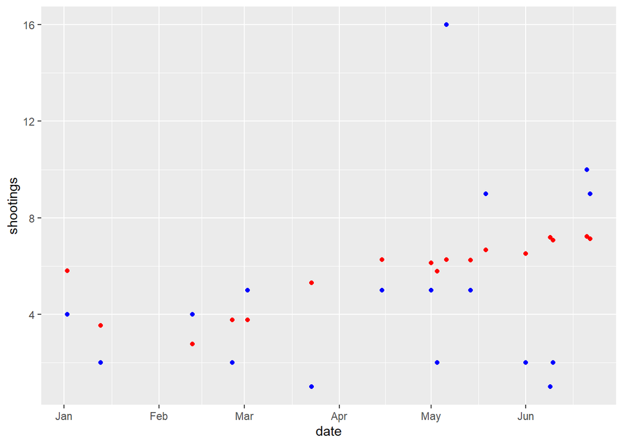

```r
covidDataWithPrediction %>% ggplot() + geom_point(aes(x = date, y = shootings), color = "blue")+
  geom_point(aes(x = date, y = fit), color ="red")
```

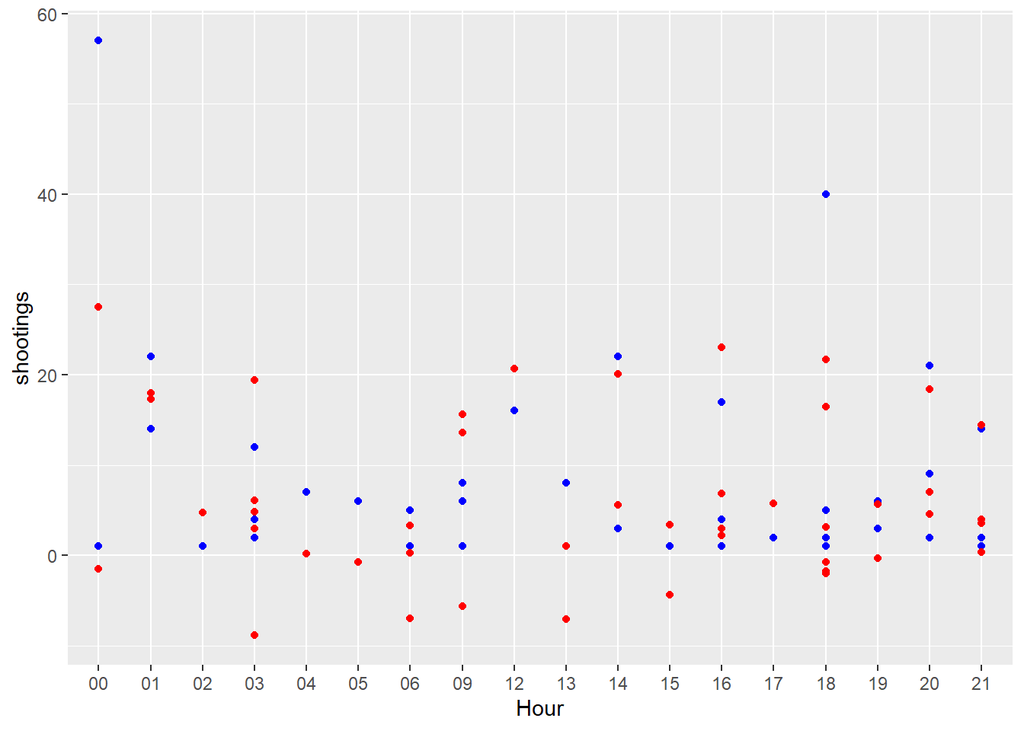

```r
multiVariateDatawPred %>% ggplot() + geom_point(aes(x = Hour, y = shootings), color = "blue")+
  geom_point(aes(x = Hour, y = fit), color ="red")
```

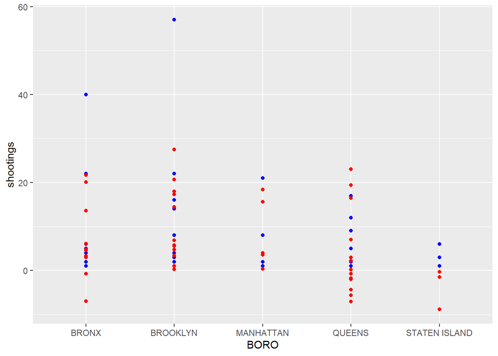

```r
multiVariateDatawPred %>% ggplot() + geom_point(aes(x = BORO, y = shootings), color = "blue")+
  geom_point(aes(x = BORO, y = fit), color ="red")
```

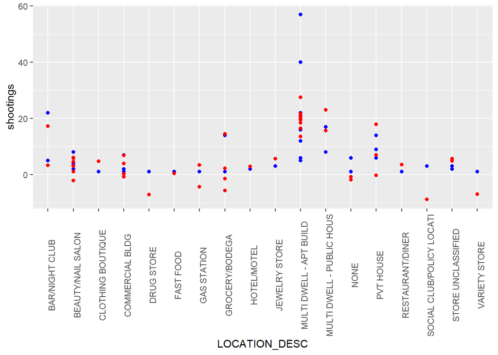

```r
multiVariateDatawPred %>% ggplot() + geom_point(aes(x = LOCATION_DESC, y = shootings), color = "blue")+
  geom_point(aes(x = LOCATION_DESC, y = fit), color ="red")+theme(axis.text.x = element_text(angle = 90))
```